신록예찬's 블로그

# (노트) ImageDataLoaders

완성

Aug 29, 2021 • 신록예찬 • 6 min read

fastai 딥러닝

- Path
- untar_data()
- get_image_files()
- Image.open()
- ImageDataLoaders.from_name_func()
  - ex1: dog vs cat
  - ex2: breed
- ImageDataLoaders.from_folder()
  - ex1: MNIST
  - ex2: iu vs hynn
- dls(dataloaders) 기능

```python
from fastai.data.all import *
from fastai.vision.all import *
```

### Path

`-` Path 클래스는 시스템에 따라서 PosixPath 혹은 WindowsPath 오브젝트를 반환한다.

```python
path=Path() # Path클래스로 부터 인스턴스 생성
```

```python
path # 현재경로 확인
```

```
Path('.')
```

```python
path?
```

```
Type:        PosixPath
String form: .
File:        ~/anaconda3/envs/2021bda/lib/python3.8/pathlib.py
Docstring:
Path subclass for non-Windows systems.

On a POSIX system, instantiating a Path should return this object.
```

`-` .ls() 메소드를 통하여 path에 저장된 파일목록을 볼 수 있다.

```python
path.ls()
```

```
(#155) [Path('2019-05-20-(리뷰) Shuman2012의 레퍼런스 정리 [기하학적 딥러닝].ipynb'),Path('2021-08-09-(연구) HST example 2 이거로하자 [기하학적 딥러닝, 논문연구].ipynb'),Path('2020-10-07-(샘플) tibble 선언 [R].ipynb'),Path('2021-08-02-(연구) HST example 1 (3) [기하학적 딥러닝, 논문연구].ipynb'),Path('2020-09-03-(노트) plt.plot [파이썬].ipynb'),Path('2021…
```

- 사실 이 메소드는 원래 `pathlib`에서 제공하는 기능이 아니라 fastai/data에서 새롭게 추가한 메소드다.

`-` .ls()메소드에서 반환되는것은 `L`타입의 자료이다.

```python
a=path.ls()
a?
```

```
Type:        L
String form: [Path('2019-05-20-(리뷰) Shuman2012의 레퍼런스 정리 [기하학적 딥러닝].ipynb'), Path('2021-08-09-(연구) HST example  <...> ith tensorflow [텐서플로우].ipynb'), Path('2021-08-02-(연구) HST example 1 (4) [기하학적 딥러닝, 논문연구].ipynb')]
Length:      155
File:        ~/anaconda3/envs/2021bda/lib/python3.8/site-packages/fastcore/foundation.py
Docstring:   Behaves like a list of `items` but can also index with list of indices or masks
```

`-` Path(...) 에서 ...에 무엇을 넣느냐에 따라서 원하는 경로를 설정할 수 있다.

```python
Path('/').ls()
```

```
(#25) [Path('/libx32'),Path('/srv'),Path('/lib64'),Path('/etc'),Path('/home'),Path('/media'),Path('/sbin'),Path('/boot'),Path('/opt'),Path('/sys')...]
```

```python
Path('/bin').ls()
```

```
(#1501) [Path('/bin/rev'),Path('/bin/aptdcon'),Path('/bin/obexctl'),Path('/bin/startx'),Path('/bin/mscompress'),Path('/bin/chvt'),Path('/bin/hp-check'),Path('/bin/sane-find-scanner'),Path('/bin/Xorg'),Path('/bin/rcp')...]
```

```python
Path('/bin/').ls()
```

```
(#1501) [Path('/bin/rev'),Path('/bin/aptdcon'),Path('/bin/obexctl'),Path('/bin/startx'),Path('/bin/mscompress'),Path('/bin/chvt'),Path('/bin/hp-check'),Path('/bin/sane-find-scanner'),Path('/bin/Xorg'),Path('/bin/rcp')...]
```

```python
Path('/home').ls()
```

```
(#1) [Path('/home/cgb4')]
```

```python
Path('/home/cgb4').ls()
```

```
(#38) [Path('/home/cgb4/.rstudio'),Path('/home/cgb4/.jupyter'),Path('/home/cgb4/.local'),Path('/home/cgb4/.nv'),Path('/home/cgb4/.R'),Path('/home/cgb4/blacklist-nouveau.conf'),Path('/home/cgb4/Dropbox'),Path('/home/cgb4/.profile'),Path('/home/cgb4/.bashrc'),Path('/home/cgb4/.ipython')...]
```

```python
Path('/home/cgb4/Dropbox').ls()
```

```
(#22) [Path('/home/cgb4/Dropbox/08_apply'),Path('/home/cgb4/Dropbox/test.zip'),Path('/home/cgb4/Dropbox/지출목록.xlsx'),Path('/home/cgb4/Dropbox/.dropbox'),Path('/home/cgb4/Dropbox/모유수유표.xlsx'),Path('/home/cgb4/Dropbox/99_temp'),Path('/home/cgb4/Dropbox/01_yechan'),Path('/home/cgb4/Dropbox/03_projects')…
```

- Path('/bin') 와 Path('/bin/')은 같은결과임

`-` PosixPath 타입과 string을 `/` 연산자로 연결하여 새로운 경로의 PosixPath 를 얻을 수 있다.

```python
Path('/home').ls()
```

```
(#1) [Path('/home/cgb4')]
```

```python
(Path('/')/'home').ls()
```

```
(#1) [Path('/home/cgb4')]
```

`-` .mkdir()을 통하여 폴더를 만들 수 있다.

```python
path_dropbox=Path('/home/cgb4/Dropbox')
```

```python
path_dropbox.ls()
```

```
(#22) [Path('/home/cgb4/Dropbox/08_apply'),Path('/home/cgb4/Dropbox/test.zip'),Path('/home/cgb4/Dropbox/지출목록.xlsx'),Path('/home/cgb4/Dropbox/.dropbox'),Path('/home/cgb4/Dropbox/모유수유표.xlsx'),Path('/home/cgb4/Dropbox/99_temp'),Path('/home/cgb4/Dropbox/01_yechan'),Path('/home/cgb4/Dropbox/03_projects')…
```

```python
(path_dropbox/'0000asdf').mkdir()
```

```python
path_dropbox.ls()
```

```
(#23) [Path('/home/cgb4/Dropbox/0000asdf'),Path('/home/cgb4/Dropbox/08_apply'),Path('/home/cgb4/Dropbox/test.zip'),Path('/home/cgb4/Dropbox/지출목록.xlsx'),Path('/home/cgb4/Dropbox/.dropbox'),Path('/home/cgb4/Dropbox/모유수유표.xlsx'),Path('/home/cgb4/Dropbox/99_temp'),Path('/home/cgb4/Dropbox/01_yechan'),Pa…
```

- 새로운 디렉토리를 만들때에는 `/`연산자를 사용해서 (path_dropbox/'0000asdf')와 같이 새로운 path를 만든 뒤에 .mkdir() 메소드를 사용한다.
- Warninig: path_dropbox.mkdir('/0000asdf')는 동작하지 않음

`-` .rmdir()을 활용하여 만든폴더를 지울수도 있다.

```python
(path_dropbox/'0000asdf').rmdir()
```

```python
path_dropbox.ls()
```

```
(#22) [Path('/home/cgb4/Dropbox/08_apply'),Path('/home/cgb4/Dropbox/test.zip'),Path('/home/cgb4/Dropbox/지출목록.xlsx'),Path('/home/cgb4/Dropbox/.dropbox'),Path('/home/cgb4/Dropbox/모유수유표.xlsx'),Path('/home/cgb4/Dropbox/99_temp'),Path('/home/cgb4/Dropbox/01_yechan'),Path('/home/cgb4/Dropbox/03_projects')…
```

`-` .name()을 활용하여 최종 폴더 혹은 파일명을 단순 string으로 반환할수 있다.

```python
path_dropbox.name # 폴더명 리턴
```

```
'Dropbox'
```

```python
(path_dropbox/'지출목록.xlsx').name # 파일명 리턴
```

```
'지출목록.xlsx'
```

### untar_data()

`-` untar_data는 fastai/data 에 소속된 함수임

```python
untar_data??
```

```
Signature:
untar_data(
    url,
    archive=None,
    data=None,
    c_key='data',
    force_download=False,
)
Source:
def untar_data(url, archive=None, data=None, c_key='data', force_download=False):#, extract_func=file_extract, timeout=4):
    "Download `url` to `fname` if `dest` doesn't exist, and extract to folder `dest`"
    d = FastDownload(fastai_cfg(), module=fastai.data, archive=archive, data=data, base='~/.fastai')
    return d.get(url, force=force_download, extract_key=c_key)
File:      ~/anaconda3/envs/2021bda/lib/python3.8/site-packages/fastai/data/external.py
Type:      function
```

`-` 주요기능: 입력으로 압축파일을 다운받을 수 있는 url을 받으면 (1) 파일을 다운받아 '~/.fastai'에 압축을 풀고 (2) 해당경로를 PosixPath 자료형으로 반환한다.

```python
path = untar_data('https://s3.amazonaws.com/fast-ai-imageclas/oxford-iiit-pet.tgz')
```

```python
path
```

```
Path('/home/cgb4/.fastai/data/oxford-iiit-pet')
```

> 압축푼 폴더이름은 압축파일이름과 같음

### get_image_files()

`-` fastai/data에 있는 함수

```python
get_image_files??
```

```
Signature: get_image_files(path, recurse=True, folders=None)
Source:
def get_image_files(path, recurse=True, folders=None):
    "Get image files in `path` recursively, only in `folders`, if specified."
    return get_files(path, extensions=image_extensions, recurse=recurse, folders=folders)
File:      ~/anaconda3/envs/2021bda/lib/python3.8/site-packages/fastai/data/transforms.py
Type:      function
```

`-` get_image_files(): 이미지폴더의 path $\to$ 폴더내의모든 이미지파일의 path의 묶음

입력: 이미지 파일이 저장된 폴더의 path

출력: 입력폴더안에서 이미지파일로 판단되는 (확장자가 .jpg 등으로 끝나는) 모든파일의 path를 모은 list. 자료형은 list대신 L을 사용함.

```python
path = untar_data('https://s3.amazonaws.com/fast-ai-imageclas/oxford-iiit-pet.tgz')
path
```

```
Path('/home/cgb4/.fastai/data/oxford-iiit-pet')
```

```python
path.ls() # 이 path에는 크게 annotations 폴더와 image 폴더가 있음.
```

```
(#2) [Path('/home/cgb4/.fastai/data/oxford-iiit-pet/annotations'),Path('/home/cgb4/.fastai/data/oxford-iiit-pet/images')]
```

```python
(path/'images').ls() # image 폴더로 이동하여 목록을 확인한다. -> 다수의 그림파일 발견 (7395개)
```

```
(#7395) [Path('/home/cgb4/.fastai/data/oxford-iiit-pet/images/staffordshire_bull_terrier_106.jpg'),Path('/home/cgb4/.fastai/data/oxford-iiit-pet/images/english_cocker_spaniel_170.jpg'),Path('/home/cgb4/.fastai/data/oxford-iiit-pet/images/leonberger_5.jpg'),Path('/home/cgb4/.fastai/data/oxford-iiit-p…
```

```python
get_image_files(path/'images') # 입력: PosixPath 타입, 출력: L 타입
```

```
(#7390) [Path('/home/cgb4/.fastai/data/oxford-iiit-pet/images/staffordshire_bull_terrier_106.jpg'),Path('/home/cgb4/.fastai/data/oxford-iiit-pet/images/english_cocker_spaniel_170.jpg'),Path('/home/cgb4/.fastai/data/oxford-iiit-pet/images/leonberger_5.jpg'),Path('/home/cgb4/.fastai/data/oxford-iiit-p…
```

```python
get_image_files(path/'images')[0] # 첫번째 이미지가 저장된 path
```

```
Path('/home/cgb4/.fastai/data/oxford-iiit-pet/images/staffordshire_bull_terrier_106.jpg')
```

### Image.open()

`-` PIL 소속함수

```python
Image.open?
```

```
Signature: Image.open(fp, mode='r', formats=None)
Docstring:
Opens and identifies the given image file.

This is a lazy operation; this function identifies the file, but
the file remains open and the actual image data is not read from
the file until you try to process the data (or call the
:py:meth:`~PIL.Image.Image.load` method).  See
:py:func:`~PIL.Image.new`. See :ref:`file-handling`.

:param fp: A filename (string), pathlib.Path object or a file object.
   The file object must implement ``file.read``,
   ``file.seek``, and ``file.tell`` methods,
   and be opened in binary mode.
:param mode: The mode.  If given, this argument must be "r".
:param formats: A list or tuple of formats to attempt to load the file in.
   This can be used to restrict the set of formats checked.
   Pass ``None`` to try all supported formats. You can print the set of
   available formats by running ``python3 -m PIL`` or using
   the :py:func:`PIL.features.pilinfo` function.
:returns: An :py:class:`~PIL.Image.Image` object.
:exception FileNotFoundError: If the file cannot be found.
:exception PIL.UnidentifiedImageError: If the image cannot be opened and
   identified.
:exception ValueError: If the ``mode`` is not "r", or if a ``StringIO``
   instance is used for ``fp``.
:exception TypeError: If ``formats`` is not ``None``, a list or a tuple.
File:      ~/anaconda3/envs/2021bda/lib/python3.8/site-packages/PIL/Image.py
Type:      function
```

`-` 이미지가 있는 path를 전달하면 진짜 이미지를 출력한다.

```python
path = untar_data('https://s3.amazonaws.com/fast-ai-imageclas/oxford-iiit-pet.tgz')
path.ls()
```

```
(#2) [Path('/home/cgb4/.fastai/data/oxford-iiit-pet/annotations'),Path('/home/cgb4/.fastai/data/oxford-iiit-pet/images')]
```

```python
get_image_files(path/'images')
```

```
(#7390) [Path('/home/cgb4/.fastai/data/oxford-iiit-pet/images/staffordshire_bull_terrier_106.jpg'),Path('/home/cgb4/.fastai/data/oxford-iiit-pet/images/english_cocker_spaniel_170.jpg'),Path('/home/cgb4/.fastai/data/oxford-iiit-pet/images/leonberger_5.jpg'),Path('/home/cgb4/.fastai/data/oxford-iiit-p…
```

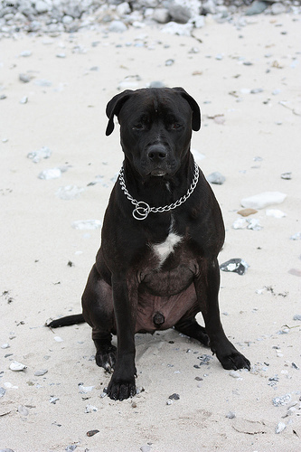

```python
Image.open(get_image_files(path/'images')[0])
```

`-` 리턴은 JpegImageFile 타입의 오브젝트

```python
firstimage= Image.open(get_image_files(path/'images')[0])
firstimage?
```

```
Type:            JpegImageFile
String form:     <PIL.JpegImagePlugin.JpegImageFile image mode=RGB size=333x500 at 0x7FEFC7A2C790>
File:            ~/anaconda3/envs/2021bda/lib/python3.8/site-packages/PIL/JpegImagePlugin.py
Docstring:       <no docstring>
Class docstring: Base class for image file format handlers.
```

`-` 이미지가 있는 path를 string의 형태로 전달해도 같은 결과임

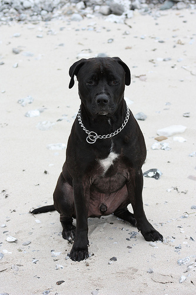

```python
Image.open('/home/cgb4/.fastai/data/oxford-iiit-pet/images/staffordshire_bull_terrier_106.jpg')
```

```python
firstimage=Image.open('/home/cgb4/.fastai/data/oxford-iiit-pet/images/staffordshire_bull_terrier_106.jpg')
firstimage?
```

```
Type:            JpegImageFile
String form:     <PIL.JpegImagePlugin.JpegImageFile image mode=RGB size=333x500 at 0x7FEFC7A2CB50>
File:            ~/anaconda3/envs/2021bda/lib/python3.8/site-packages/PIL/JpegImagePlugin.py
Docstring:       <no docstring>
Class docstring: Base class for image file format handlers.
```

### ImageDataLoaders.from_name_func()

**사용조건: 파일명에서 카테고리를 유추할 수 있는 경우**

#### ex1: dog vs cat

`-` ImageDataLoaders는 fastai/vision에서 ImageDataLoaders class에 정의된 class method임

```python
ImageDataLoaders.from_name_func??
```

```
Signature:
ImageDataLoaders.from_name_func(
    path,
    fnames,
    label_func,
    valid_pct=0.2,
    seed=None,
    item_tfms=None,
    batch_tfms=None,
    bs=64,
    val_bs=None,
    shuffle=True,
    device=None,
)
Source:
    @classmethod
    def from_name_func(cls, path, fnames, label_func, **kwargs):
        "Create from the name attrs of `fnames` in `path`s with `label_func`"
        if sys.platform == 'win32' and isinstance(label_func, types.LambdaType) and label_func.__name__ == '<lambda>':
            # https://medium.com/@jwnx/multiprocessing-serialization-in-python-with-pickle-9844f6fa1812
            raise ValueError("label_func couldn't be lambda function on Windows")
        f = using_attr(label_func, 'name')
        return cls.from_path_func(path, fnames, f, **kwargs)
File:      ~/anaconda3/envs/2021bda/lib/python3.8/site-packages/fastai/vision/data.py
Type:      method
```

- 필수요소는 path, fnames, label_func 이다.
- 그런데 이미지의 크기가 다르면 학습이 불가능하므로 (CNN특징) 사실상 item_tfms 역시 필수요소라 할 수 있다.

`-` label_func을 아래와 같이 정의하자

```python
def label_func(fname):
    return "cat" if fname[0].isupper() else "dog" # 파일명의 첫번짜 글자가 대문자이면 cat
```

```python
label_func('aSdf')
```

```
'dog'
```

```python
label_func('Asdf')
```

```
'cat'
```

`-` dataloaders 만들기

```python
path = untar_data('https://s3.amazonaws.com/fast-ai-imageclas/oxford-iiit-pet.tgz')
path.ls()
```

```
(#2) [Path('/home/cgb4/.fastai/data/oxford-iiit-pet/annotations'),Path('/home/cgb4/.fastai/data/oxford-iiit-pet/images')]
```

```python
dls=ImageDataLoaders.from_name_func(path/'images',
                                    get_image_files(path/'images'),
                                    label_func,
                                    item_tfms=Resize(224))
```

- path: 이미지파일들이 위치한 폴더를 PosixPath 형태로 전달
- fnames: 폴더내의모든 이미지파일의 path의 묶음을 리스트형태로 전달. 여기에서는 L 타입을 사용.
- label_func: 파일명 $\to$ 카테고리
- item_tfms: 분석이 용이하도록 이미지데이터를 정리하는 전처리함수.보통 Resize() 이용

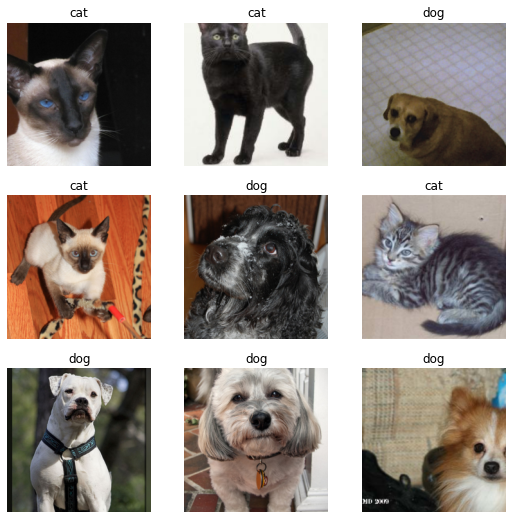

```python
dls.show_batch(max_n=9)
```

`-` fnames를 L 타입이 아니라 list, tuple 로 전달하여도 괜찮음.

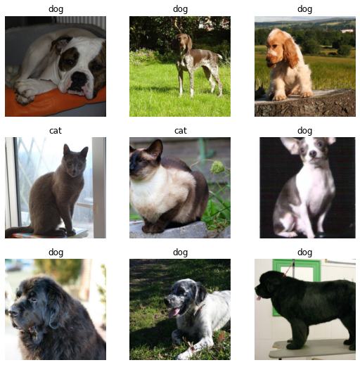

```python
dls=ImageDataLoaders.from_name_func(path/'images',
                                    list(get_image_files(path/'images')),
                                    label_func,
                                    item_tfms=Resize(224))
dls.show_batch(max_n=9)
```

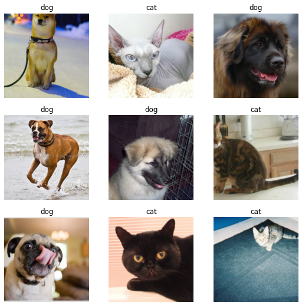

```python
dls=ImageDataLoaders.from_name_func(path/'images',
                                    tuple(get_image_files(path/'images')),
                                    label_func,
                                    item_tfms=Resize(224))
dls.show_batch(max_n=9)
```

#### ex2: breed

`-` 준비

```python
path = untar_data('https://s3.amazonaws.com/fast-ai-imageclas/oxford-iiit-pet.tgz')
path.ls()
```

```
(#2) [Path('/home/cgb4/.fastai/data/oxford-iiit-pet/annotations'),Path('/home/cgb4/.fastai/data/oxford-iiit-pet/images')]
```

```python
get_image_files(path/'images')
```

```
(#7390) [Path('/home/cgb4/.fastai/data/oxford-iiit-pet/images/staffordshire_bull_terrier_106.jpg'),Path('/home/cgb4/.fastai/data/oxford-iiit-pet/images/english_cocker_spaniel_170.jpg'),Path('/home/cgb4/.fastai/data/oxford-iiit-pet/images/leonberger_5.jpg'),Path('/home/cgb4/.fastai/data/oxford-iiit-p…
```

`-` 파일명을 관찰하니 `품종_숫자.jpg` 형태임

`-` 파일명에서 품종을 추출하고 싶음

`-` 우선파일명에 접근하려면 path에서 .name 을 사용

```python
get_image_files(path/'images')[0]
```

```
Path('/home/cgb4/.fastai/data/oxford-iiit-pet/images/staffordshire_bull_terrier_106.jpg')
```

```python
get_image_files(path/'images')[0].name
```

```
'staffordshire_bull_terrier_106.jpg'
```

`-` 품종을 추출하기 위해서 정규표현식 이용

```python
re.findall(r'(.+)_\d+.jpg$',get_image_files(path/'images')[0].name)
```

```
['staffordshire_bull_terrier']
```

- re.findall 은 파이썬 자체에서 지원하는 함수임

결과를 리스트가 아니라 string으로 만들기 위해서

```python
re.findall(r'(.+)_\d+.jpg$',get_image_files(path/'images')[0].name)[0]
```

```
'staffordshire_bull_terrier'
```

`-` 라벨링함수 정의

```python
def label_func(fname):
    return re.findall(r'(.+)_\d+.jpg$',fname)[0] # 끝에 [0]을 붙여야 결과가 스트링으로 된다.
```

`-` dataloaders 만들기

```python
dls=ImageDataLoaders.from_name_func(path/'images',
                                    get_image_files(path/'images'),
                                    label_func,
                                    item_tfms=Resize(224))
```

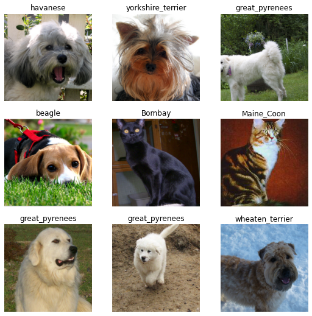

```python
dls.show_batch(max_n=9)
```

### ImageDataLoaders.from_folder()

**사용조건: 카테고리가 폴더별로 정리되어있는 경우**

#### ex1: MNIST

```python
path = untar_data(URLs.MNIST)
```

```python
path.ls()
```

```
(#2) [Path('/home/cgb4/.fastai/data/mnist_png/training'),Path('/home/cgb4/.fastai/data/mnist_png/testing')]
```

```python
(path/'training').ls()
```

```
(#10) [Path('/home/cgb4/.fastai/data/mnist_png/training/5'),Path('/home/cgb4/.fastai/data/mnist_png/training/3'),Path('/home/cgb4/.fastai/data/mnist_png/training/2'),Path('/home/cgb4/.fastai/data/mnist_png/training/6'),Path('/home/cgb4/.fastai/data/mnist_png/training/8'),Path('/home/cgb4/.fastai/dat…
```

```python
(path/'training/7').ls()
```

```
(#6265) [Path('/home/cgb4/.fastai/data/mnist_png/training/7/39261.png'),Path('/home/cgb4/.fastai/data/mnist_png/training/7/25756.png'),Path('/home/cgb4/.fastai/data/mnist_png/training/7/33304.png'),Path('/home/cgb4/.fastai/data/mnist_png/training/7/24207.png'),Path('/home/cgb4/.fastai/data/mnist_png…
```

```python
(path/'testing/7').ls()
```

```
(#1028) [Path('/home/cgb4/.fastai/data/mnist_png/testing/7/9515.png'),Path('/home/cgb4/.fastai/data/mnist_png/testing/7/7419.png'),Path('/home/cgb4/.fastai/data/mnist_png/testing/7/6679.png'),Path('/home/cgb4/.fastai/data/mnist_png/testing/7/7439.png'),Path('/home/cgb4/.fastai/data/mnist_png/testing…
```

`-` 이미지구경

```python
Image.open('/home/cgb4/.fastai/data/mnist_png/testing/7/9515.png')
```

[output not shown]

`-` dls 만들기

```python
ImageDataLoaders.from_folder?
```

```
Signature:
ImageDataLoaders.from_folder(
    path,
    train='train',
    valid='valid',
    valid_pct=None,
    seed=None,
    vocab=None,
    item_tfms=None,
    batch_tfms=None,
    bs=64,
    val_bs=None,
    shuffle=True,
    device=None,
)
Docstring: Create from imagenet style dataset in `path` with `train` and `valid` subfolders (or provide `valid_pct`)
File:      ~/anaconda3/envs/2021bda/lib/python3.8/site-packages/fastai/vision/data.py
Type:      method
```

- path: 데이터가 모여진 폴더
- train: training set이 있는 폴더
- valid: validation set이 있는 폴더 (있을경우 쓴다)
- valid_pct: training set에서 일부를 validation set으로 사용할 경우 사용한다.

```python
dls=ImageDataLoaders.from_folder(path,train='training',valid_pct=0.2)
```

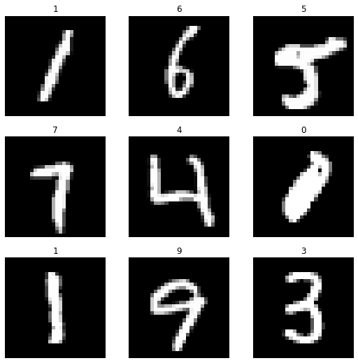

```python
dls.show_batch()
```

#### ex2: iu vs hynn

```python
path=Path('./singer')
fns=get_image_files(path)
failed=verify_images(fns)
failed
```

```
(#0) []
```

```python
failed.map(Path.unlink);
```

```python
dls=ImageDataLoaders.from_folder(path,train='singer',valid_pct=0.2,item_tfms=Resize(128))
```

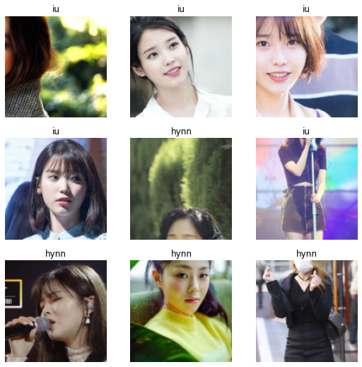

```python
dls.show_batch()
```

### dls(dataloaders) 기능

```python
dls.vocab
```

```
['hynn', 'iu']
```